# Risk Factor Analysis

## Outcome Variable

**Outcome Variable:** whz

## Predictor Variables

**Intervention Variable:** brthmon

**Adjustment Set:**

unadjusted

## Stratifying Variables

The analysis was stratified on these variable(s):

- agecat
- studyid
- country

## Data Summary

| agecat | studyid | country | brthmon | n_cell | n | outcome_variable |
| --- | --- | --- | --- | --- | --- | --- |
| Birth | CMC-V-BCS-2002 | INDIA | 1 | 9 | 86 | whz |
| Birth | CMC-V-BCS-2002 | INDIA | 2 | 1 | 86 | whz |
| Birth | CMC-V-BCS-2002 | INDIA | 3 | 7 | 86 | whz |
| Birth | CMC-V-BCS-2002 | INDIA | 4 | 9 | 86 | whz |
| Birth | CMC-V-BCS-2002 | INDIA | 5 | 10 | 86 | whz |
| Birth | CMC-V-BCS-2002 | INDIA | 6 | 9 | 86 | whz |
| Birth | CMC-V-BCS-2002 | INDIA | 7 | 7 | 86 | whz |
| Birth | CMC-V-BCS-2002 | INDIA | 8 | 4 | 86 | whz |
| Birth | CMC-V-BCS-2002 | INDIA | 9 | 8 | 86 | whz |
| Birth | CMC-V-BCS-2002 | INDIA | 10 | 8 | 86 | whz |
| Birth | CMC-V-BCS-2002 | INDIA | 11 | 11 | 86 | whz |
| Birth | CMC-V-BCS-2002 | INDIA | 12 | 3 | 86 | whz |
| Birth | CMIN | BANGLADESH | 1 | 2 | 19 | whz |
| Birth | CMIN | BANGLADESH | 2 | 4 | 19 | whz |
| Birth | CMIN | BANGLADESH | 3 | 0 | 19 | whz |
| Birth | CMIN | BANGLADESH | 4 | 2 | 19 | whz |
| Birth | CMIN | BANGLADESH | 5 | 1 | 19 | whz |
| Birth | CMIN | BANGLADESH | 6 | 0 | 19 | whz |
| Birth | CMIN | BANGLADESH | 7 | 4 | 19 | whz |
| Birth | CMIN | BANGLADESH | 8 | 2 | 19 | whz |
| Birth | CMIN | BANGLADESH | 9 | 1 | 19 | whz |
| Birth | CMIN | BANGLADESH | 10 | 1 | 19 | whz |
| Birth | CMIN | BANGLADESH | 11 | 2 | 19 | whz |
| Birth | CMIN | BANGLADESH | 12 | 0 | 19 | whz |
| Birth | CONTENT | PERU | 1 | 0 | 2 | whz |
| Birth | CONTENT | PERU | 2 | 0 | 2 | whz |
| Birth | CONTENT | PERU | 3 | 0 | 2 | whz |
| Birth | CONTENT | PERU | 4 | 0 | 2 | whz |
| Birth | CONTENT | PERU | 5 | 2 | 2 | whz |
| Birth | CONTENT | PERU | 6 | 0 | 2 | whz |

[output cut: 810 more lines]

The following strata were considered:

- agecat: 24 months, studyid: CMC-V-BCS-2002, country: INDIA
- agecat: 24 months, studyid: CMIN, country: BANGLADESH
- agecat: 24 months, studyid: CONTENT, country: PERU
- agecat: 24 months, studyid: EE, country: PAKISTAN
- agecat: 24 months, studyid: GMS-Nepal, country: NEPAL
- agecat: 24 months, studyid: IRC, country: INDIA
- agecat: 24 months, studyid: JiVitA-3, country: BANGLADESH
- agecat: 24 months, studyid: JiVitA-4, country: BANGLADESH
- agecat: 24 months, studyid: Keneba, country: GAMBIA
- agecat: 24 months, studyid: LCNI-5, country: MALAWI
- agecat: 24 months, studyid: MAL-ED, country: BANGLADESH
- agecat: 24 months, studyid: MAL-ED, country: BRAZIL
- agecat: 24 months, studyid: MAL-ED, country: INDIA
- agecat: 24 months, studyid: MAL-ED, country: NEPAL
- agecat: 24 months, studyid: MAL-ED, country: PERU
- agecat: 24 months, studyid: MAL-ED, country: SOUTH AFRICA
- agecat: 24 months, studyid: MAL-ED, country: TANZANIA, UNITED REPUBLIC OF
- agecat: 24 months, studyid: NIH-Birth, country: BANGLADESH
- agecat: 24 months, studyid: PROBIT, country: BELARUS
- agecat: 24 months, studyid: PROVIDE, country: BANGLADESH
- agecat: 24 months, studyid: TanzaniaChild2, country: TANZANIA, UNITED REPUBLIC OF
- agecat: 24 months, studyid: ZVITAMBO, country: ZIMBABWE
- agecat: 6 months, studyid: CMC-V-BCS-2002, country: INDIA
- agecat: 6 months, studyid: CMIN, country: BANGLADESH
- agecat: 6 months, studyid: CONTENT, country: PERU
- agecat: 6 months, studyid: EE, country: PAKISTAN
- agecat: 6 months, studyid: GMS-Nepal, country: NEPAL
- agecat: 6 months, studyid: Guatemala BSC, country: GUATEMALA
- agecat: 6 months, studyid: IRC, country: INDIA
- agecat: 6 months, studyid: JiVitA-3, country: BANGLADESH
- agecat: 6 months, studyid: JiVitA-4, country: BANGLADESH
- agecat: 6 months, studyid: Keneba, country: GAMBIA
- agecat: 6 months, studyid: LCNI-5, country: MALAWI
- agecat: 6 months, studyid: MAL-ED, country: BANGLADESH
- agecat: 6 months, studyid: MAL-ED, country: BRAZIL
- agecat: 6 months, studyid: MAL-ED, country: INDIA
- agecat: 6 months, studyid: MAL-ED, country: NEPAL
- agecat: 6 months, studyid: MAL-ED, country: PERU
- agecat: 6 months, studyid: MAL-ED, country: SOUTH AFRICA
- agecat: 6 months, studyid: MAL-ED, country: TANZANIA, UNITED REPUBLIC OF
- agecat: 6 months, studyid: NIH-Birth, country: BANGLADESH
- agecat: 6 months, studyid: PROBIT, country: BELARUS
- agecat: 6 months, studyid: PROVIDE, country: BANGLADESH
- agecat: 6 months, studyid: ResPak, country: PAKISTAN
- agecat: 6 months, studyid: SAS-CompFeed, country: INDIA
- agecat: 6 months, studyid: SAS-FoodSuppl, country: INDIA
- agecat: 6 months, studyid: TanzaniaChild2, country: TANZANIA, UNITED REPUBLIC OF
- agecat: 6 months, studyid: ZVITAMBO, country: ZIMBABWE
- agecat: Birth, studyid: CMC-V-BCS-2002, country: INDIA
- agecat: Birth, studyid: CMIN, country: BANGLADESH
- agecat: Birth, studyid: CONTENT, country: PERU
- agecat: Birth, studyid: EE, country: PAKISTAN
- agecat: Birth, studyid: GMS-Nepal, country: NEPAL
- agecat: Birth, studyid: IRC, country: INDIA
- agecat: Birth, studyid: JiVitA-3, country: BANGLADESH
- agecat: Birth, studyid: JiVitA-4, country: BANGLADESH
- agecat: Birth, studyid: Keneba, country: GAMBIA
- agecat: Birth, studyid: MAL-ED, country: BANGLADESH
- agecat: Birth, studyid: MAL-ED, country: BRAZIL
- agecat: Birth, studyid: MAL-ED, country: INDIA
- agecat: Birth, studyid: MAL-ED, country: NEPAL
- agecat: Birth, studyid: MAL-ED, country: PERU
- agecat: Birth, studyid: MAL-ED, country: SOUTH AFRICA
- agecat: Birth, studyid: MAL-ED, country: TANZANIA, UNITED REPUBLIC OF
- agecat: Birth, studyid: NIH-Birth, country: BANGLADESH
- agecat: Birth, studyid: PROBIT, country: BELARUS
- agecat: Birth, studyid: PROVIDE, country: BANGLADESH
- agecat: Birth, studyid: ResPak, country: PAKISTAN
- agecat: Birth, studyid: SAS-CompFeed, country: INDIA
- agecat: Birth, studyid: ZVITAMBO, country: ZIMBABWE

### Dropped Strata

Some strata were dropped due to rare outcomes:

- agecat: Birth, studyid: CMC-V-BCS-2002, country: INDIA
- agecat: Birth, studyid: CMIN, country: BANGLADESH
- agecat: Birth, studyid: CONTENT, country: PERU
- agecat: Birth, studyid: EE, country: PAKISTAN
- agecat: Birth, studyid: GMS-Nepal, country: NEPAL
- agecat: Birth, studyid: JiVitA-4, country: BANGLADESH
- agecat: Birth, studyid: MAL-ED, country: BRAZIL
- agecat: Birth, studyid: MAL-ED, country: INDIA
- agecat: Birth, studyid: MAL-ED, country: NEPAL
- agecat: Birth, studyid: MAL-ED, country: SOUTH AFRICA
- agecat: Birth, studyid: MAL-ED, country: TANZANIA, UNITED REPUBLIC OF
- agecat: Birth, studyid: ResPak, country: PAKISTAN
- agecat: 6 months, studyid: EE, country: PAKISTAN
- agecat: 6 months, studyid: GMS-Nepal, country: NEPAL
- agecat: 6 months, studyid: JiVitA-4, country: BANGLADESH
- agecat: 6 months, studyid: ResPak, country: PAKISTAN
- agecat: 6 months, studyid: SAS-FoodSuppl, country: INDIA
- agecat: 24 months, studyid: EE, country: PAKISTAN
- agecat: 24 months, studyid: GMS-Nepal, country: NEPAL
- agecat: 24 months, studyid: JiVitA-4, country: BANGLADESH
- agecat: 24 months, studyid: TanzaniaChild2, country: TANZANIA, UNITED REPUBLIC OF
- agecat: 24 months, studyid: ZVITAMBO, country: ZIMBABWE

## Methods Detail

We’re interested in the causal parameters $E[Y_a]$ for all values of $a \in \mathcal{A}$. These parameters represent the mean outcome if, possibly contrary to fact, we intervened to set all units to have $A=a$. Under the randomization and positivity assumptions, these are identified by the statistical parameters $\psi_a=E_W[E_{Y|A,W}(Y|A=a,W)]$. In addition, we’re interested in the mean of $Y$, $E[Y]$ under no intervention (the observed mean). We will estimate these parameters by using SuperLearner to fit the relevant likelihood factors – $E_{Y|A,W}(Y|A=a,W)$ and $p(A=a|W)$, and then updating our likelihood fit using a joint TMLE.

For unadjusted analyses ($W=\{\}$), initial likelihoods were estimated using Lrnr_glm to estimate the simple $E(Y|A)$ and Lrnr_mean to estimate $p(A)$. For adjusted analyses, a small library containing Lrnr_glmnet, Lrnr_xgboost, and Lrnr_mean was used.

Having estimated these parameters, we will then use the delta method to estimate relative risks and attributable risks relative to a prespecified baseline level of $A$.

# Results Detail

## Results Plots

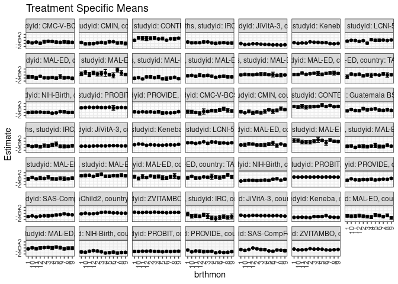

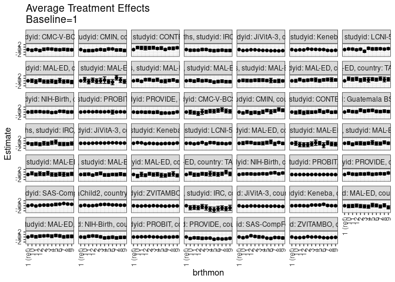

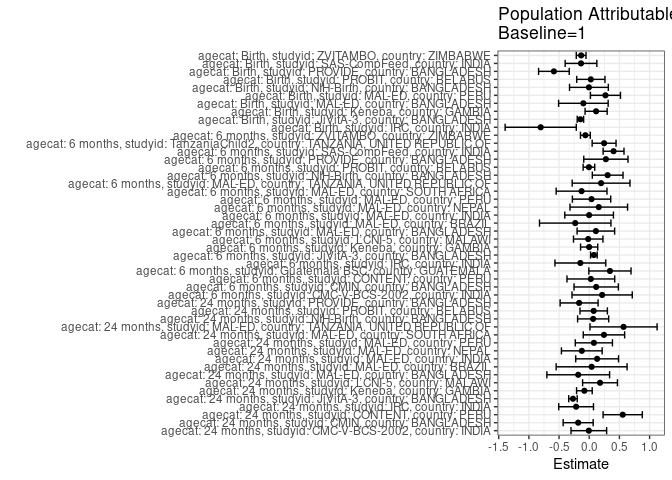

## Results Table

### Parameter: TSM

| agecat | studyid | country | intervention_level | baseline_level | estimate | ci_lower | ci_upper |
| --- | --- | --- | --- | --- | --- | --- | --- |
| Birth | IRC | INDIA | 1 | NA | -0.2064516 | -0.8241587 | 0.4112554 |
| Birth | IRC | INDIA | 2 | NA | -0.5304348 | -1.0966348 | 0.0357652 |
| Birth | IRC | INDIA | 3 | NA | -0.8991667 | -1.7172346 | -0.0810988 |
| Birth | IRC | INDIA | 4 | NA | -1.5168421 | -2.1488141 | -0.8848701 |
| Birth | IRC | INDIA | 5 | NA | -1.7686667 | -2.5910096 | -0.9463238 |
| Birth | IRC | INDIA | 6 | NA | -1.3615385 | -2.0604069 | -0.6626700 |
| Birth | IRC | INDIA | 7 | NA | -1.0848387 | -1.6762039 | -0.4934735 |
| Birth | IRC | INDIA | 8 | NA | -1.3869444 | -1.9532683 | -0.8206205 |
| Birth | IRC | INDIA | 9 | NA | -1.0200000 | -1.8383304 | -0.2016696 |
| Birth | IRC | INDIA | 10 | NA | -0.9990909 | -1.5750645 | -0.4231173 |
| Birth | IRC | INDIA | 11 | NA | -0.8418421 | -1.3887010 | -0.2949832 |
| Birth | IRC | INDIA | 12 | NA | -0.9930233 | -1.4781855 | -0.5078611 |
| Birth | JiVitA-3 | BANGLADESH | 1 | NA | -0.6317930 | -0.6892360 | -0.5743500 |
| Birth | JiVitA-3 | BANGLADESH | 2 | NA | -0.7167943 | -0.7728395 | -0.6607492 |
| Birth | JiVitA-3 | BANGLADESH | 3 | NA | -0.7718027 | -0.8220441 | -0.7215613 |
| Birth | JiVitA-3 | BANGLADESH | 4 | NA | -0.7763052 | -0.8353053 | -0.7173051 |
| Birth | JiVitA-3 | BANGLADESH | 5 | NA | -0.7791250 | -0.8517791 | -0.7064709 |
| Birth | JiVitA-3 | BANGLADESH | 6 | NA | -0.8001622 | -0.8681817 | -0.7321426 |
| Birth | JiVitA-3 | BANGLADESH | 7 | NA | -0.7512653 | -0.8144339 | -0.6880968 |
| Birth | JiVitA-3 | BANGLADESH | 8 | NA | -0.8435644 | -0.9029217 | -0.7842070 |
| Birth | JiVitA-3 | BANGLADESH | 9 | NA | -0.9139817 | -0.9686963 | -0.8592670 |
| Birth | JiVitA-3 | BANGLADESH | 10 | NA | -0.8499010 | -0.9017269 | -0.7980751 |
| Birth | JiVitA-3 | BANGLADESH | 11 | NA | -0.7938410 | -0.8445187 | -0.7431633 |
| Birth | JiVitA-3 | BANGLADESH | 12 | NA | -0.6929369 | -0.7442469 | -0.6416268 |
| Birth | Keneba | GAMBIA | 1 | NA | -1.3488889 | -1.5422100 | -1.1555678 |
| Birth | Keneba | GAMBIA | 2 | NA | -1.4002857 | -1.5922534 | -1.2083180 |
| Birth | Keneba | GAMBIA | 3 | NA | -1.0693082 | -1.2476477 | -0.8909687 |
| Birth | Keneba | GAMBIA | 4 | NA | -1.0735922 | -1.3043402 | -0.8428443 |
| Birth | Keneba | GAMBIA | 5 | NA | -1.0514706 | -1.2875250 | -0.8154162 |
| Birth | Keneba | GAMBIA | 6 | NA | -0.7711765 | -1.0420592 | -0.5002937 |

[output cut: 546 more lines]

### Parameter: E(Y)

| agecat | studyid | country | intervention_level | baseline_level | estimate | ci_lower | ci_upper |
| --- | --- | --- | --- | --- | --- | --- | --- |
| Birth | IRC | INDIA | NA | NA | -1.0105831 | -1.1973019 | -0.8238643 |
| Birth | JiVitA-3 | BANGLADESH | NA | NA | -0.7778272 | -0.7968313 | -0.7588232 |
| Birth | Keneba | GAMBIA | NA | NA | -1.2349454 | -1.2972413 | -1.1726496 |
| Birth | MAL-ED | BANGLADESH | NA | NA | -0.9418605 | -1.0869834 | -0.7967375 |
| Birth | MAL-ED | PERU | NA | NA | -0.0520175 | -0.1725298 | 0.0684947 |
| Birth | NIH-Birth | BANGLADESH | NA | NA | -1.3499217 | -1.4444634 | -1.2553801 |
| Birth | PROBIT | BELARUS | NA | NA | -1.1491782 | -1.3593933 | -0.9389630 |
| Birth | PROVIDE | BANGLADESH | NA | NA | -1.2984586 | -1.3752758 | -1.2216415 |
| Birth | SAS-CompFeed | INDIA | NA | NA | -0.6700453 | -0.8474950 | -0.4925957 |
| Birth | ZVITAMBO | ZIMBABWE | NA | NA | -0.5154897 | -0.5413479 | -0.4896314 |
| 6 months | CMC-V-BCS-2002 | INDIA | NA | NA | -0.5026766 | -0.6536848 | -0.3516685 |
| 6 months | CMIN | BANGLADESH | NA | NA | -0.5780453 | -0.7226627 | -0.4334279 |
| 6 months | CONTENT | PERU | NA | NA | 1.0644279 | 0.9468682 | 1.1819876 |
| 6 months | Guatemala BSC | GUATEMALA | NA | NA | -0.0840134 | -0.1945572 | 0.0265305 |
| 6 months | IRC | INDIA | NA | NA | -0.5989297 | -0.7344491 | -0.4634104 |
| 6 months | JiVitA-3 | BANGLADESH | NA | NA | -0.5935161 | -0.6130518 | -0.5739805 |
| 6 months | Keneba | GAMBIA | NA | NA | -0.1846038 | -0.2354782 | -0.1337293 |
| 6 months | LCNI-5 | MALAWI | NA | NA | 0.4499404 | 0.3788501 | 0.5210308 |
| 6 months | MAL-ED | BANGLADESH | NA | NA | -0.1376763 | -0.2664642 | -0.0088885 |
| 6 months | MAL-ED | BRAZIL | NA | NA | 0.9720774 | 0.8078144 | 1.1363403 |
| 6 months | MAL-ED | INDIA | NA | NA | -0.7079979 | -0.8344175 | -0.5815783 |
| 6 months | MAL-ED | NEPAL | NA | NA | 0.1104308 | -0.0208643 | 0.2417259 |
| 6 months | MAL-ED | PERU | NA | NA | 1.0528816 | 0.9313005 | 1.1744626 |
| 6 months | MAL-ED | SOUTH AFRICA | NA | NA | 0.5421785 | 0.3900443 | 0.6943126 |
| 6 months | MAL-ED | TANZANIA, UNITED REPUBLIC OF | NA | NA | 0.5362213 | 0.4049390 | 0.6675036 |
| 6 months | NIH-Birth | BANGLADESH | NA | NA | -0.4474038 | -0.5378167 | -0.3569909 |
| 6 months | PROBIT | BELARUS | NA | NA | 0.5741099 | 0.5141290 | 0.6340908 |
| 6 months | PROVIDE | BANGLADESH | NA | NA | -0.1990907 | -0.2817968 | -0.1163845 |
| 6 months | SAS-CompFeed | INDIA | NA | NA | -0.6657084 | -0.8024377 | -0.5289791 |
| 6 months | TanzaniaChild2 | TANZANIA, UNITED REPUBLIC OF | NA | NA | 0.0809332 | 0.0282644 | 0.1336020 |
| 6 months | ZVITAMBO | ZIMBABWE | NA | NA | 0.3105514 | 0.2848767 | 0.3362262 |
| 24 months | CMC-V-BCS-2002 | INDIA | NA | NA | -0.5571505 | -0.6585247 | -0.4557763 |
| 24 months | CMIN | BANGLADESH | NA | NA | -0.8535391 | -0.9644236 | -0.7426546 |
| 24 months | CONTENT | PERU | NA | NA | 0.5902439 | 0.4560143 | 0.7244735 |
| 24 months | IRC | INDIA | NA | NA | -0.7458150 | -0.8368180 | -0.6548120 |
| 24 months | JiVitA-3 | BANGLADESH | NA | NA | -1.2978031 | -1.3210763 | -1.2745298 |
| 24 months | Keneba | GAMBIA | NA | NA | -0.8099290 | -0.8570608 | -0.7627972 |
| 24 months | LCNI-5 | MALAWI | NA | NA | -0.0477709 | -0.1296526 | 0.0341109 |
| 24 months | MAL-ED | BANGLADESH | NA | NA | -0.8192925 | -0.9412667 | -0.6973182 |
| 24 months | MAL-ED | BRAZIL | NA | NA | 0.4626233 | 0.2567495 | 0.6684971 |
| 24 months | MAL-ED | INDIA | NA | NA | -0.9516520 | -1.0670654 | -0.8362385 |
| 24 months | MAL-ED | NEPAL | NA | NA | -0.3749123 | -0.4886073 | -0.2612173 |
| 24 months | MAL-ED | PERU | NA | NA | 0.1111982 | -0.0118399 | 0.2342362 |
| 24 months | MAL-ED | SOUTH AFRICA | NA | NA | 0.4090301 | 0.2879441 | 0.5301161 |
| 24 months | MAL-ED | TANZANIA, UNITED REPUBLIC OF | NA | NA | 0.0547975 | -0.0703378 | 0.1799328 |
| 24 months | NIH-Birth | BANGLADESH | NA | NA | -0.9115790 | -1.0095022 | -0.8136559 |
| 24 months | PROBIT | BELARUS | NA | NA | 0.6981406 | 0.5843775 | 0.8119038 |
| 24 months | PROVIDE | BANGLADESH | NA | NA | -0.8928670 | -0.9755153 | -0.8102187 |

### Parameter: ATE

| agecat | studyid | country | intervention_level | baseline_level | estimate | ci_lower | ci_upper |
| --- | --- | --- | --- | --- | --- | --- | --- |
| Birth | IRC | INDIA | 1 | 1 | 0.0000000 | 0.0000000 | 0.0000000 |
| Birth | IRC | INDIA | 2 | 1 | -0.3239832 | -1.1619238 | 0.5139574 |
| Birth | IRC | INDIA | 3 | 1 | -0.6927151 | -1.7177990 | 0.3323689 |
| Birth | IRC | INDIA | 4 | 1 | -1.3103905 | -2.1941046 | -0.4266764 |
| Birth | IRC | INDIA | 5 | 1 | -1.5622151 | -2.5907139 | -0.5337162 |
| Birth | IRC | INDIA | 6 | 1 | -1.1550868 | -2.0878136 | -0.2223601 |
| Birth | IRC | INDIA | 7 | 1 | -0.8783871 | -1.7335332 | -0.0232410 |
| Birth | IRC | INDIA | 8 | 1 | -1.1804928 | -2.0185171 | -0.3424685 |
| Birth | IRC | INDIA | 9 | 1 | -0.8135484 | -1.8388418 | 0.2117450 |
| Birth | IRC | INDIA | 10 | 1 | -0.7926393 | -1.6372147 | 0.0519361 |
| Birth | IRC | INDIA | 11 | 1 | -0.6353905 | -1.4603854 | 0.1896045 |
| Birth | IRC | INDIA | 12 | 1 | -0.7865716 | -1.5720297 | -0.0011136 |
| Birth | JiVitA-3 | BANGLADESH | 1 | 1 | 0.0000000 | 0.0000000 | 0.0000000 |
| Birth | JiVitA-3 | BANGLADESH | 2 | 1 | -0.0850014 | -0.1633104 | -0.0066923 |
| Birth | JiVitA-3 | BANGLADESH | 3 | 1 | -0.1400097 | -0.2157769 | -0.0642425 |
| Birth | JiVitA-3 | BANGLADESH | 4 | 1 | -0.1445122 | -0.2264789 | -0.0625456 |
| Birth | JiVitA-3 | BANGLADESH | 5 | 1 | -0.1473320 | -0.2399252 | -0.0547389 |
| Birth | JiVitA-3 | BANGLADESH | 6 | 1 | -0.1683692 | -0.2554918 | -0.0812466 |
| Birth | JiVitA-3 | BANGLADESH | 7 | 1 | -0.1194724 | -0.2031072 | -0.0358376 |
| Birth | JiVitA-3 | BANGLADESH | 8 | 1 | -0.2117714 | -0.2937996 | -0.1297432 |
| Birth | JiVitA-3 | BANGLADESH | 9 | 1 | -0.2821887 | -0.3592823 | -0.2050951 |
| Birth | JiVitA-3 | BANGLADESH | 10 | 1 | -0.2181080 | -0.2950189 | -0.1411972 |
| Birth | JiVitA-3 | BANGLADESH | 11 | 1 | -0.1620480 | -0.2355223 | -0.0885737 |
| Birth | JiVitA-3 | BANGLADESH | 12 | 1 | -0.0611439 | -0.1341478 | 0.0118600 |
| Birth | Keneba | GAMBIA | 1 | 1 | 0.0000000 | 0.0000000 | 0.0000000 |
| Birth | Keneba | GAMBIA | 2 | 1 | -0.0513968 | -0.3238388 | 0.2210452 |
| Birth | Keneba | GAMBIA | 3 | 1 | 0.2795807 | 0.0165635 | 0.5425979 |
| Birth | Keneba | GAMBIA | 4 | 1 | 0.2752967 | -0.0257310 | 0.5763244 |
| Birth | Keneba | GAMBIA | 5 | 1 | 0.2974183 | -0.0076960 | 0.6025326 |
| Birth | Keneba | GAMBIA | 6 | 1 | 0.5777124 | 0.2449204 | 0.9105044 |

[output cut: 546 more lines]

### Parameter: PAR

| agecat | studyid | country | intervention_level | baseline_level | estimate | ci_lower | ci_upper |
| --- | --- | --- | --- | --- | --- | --- | --- |
| Birth | IRC | INDIA | 1 | NA | -0.8041315 | -1.3935851 | -0.2146779 |
| Birth | JiVitA-3 | BANGLADESH | 1 | NA | -0.1460343 | -0.1992204 | -0.0928481 |
| Birth | Keneba | GAMBIA | 1 | NA | 0.1139435 | -0.0689579 | 0.2968448 |
| Birth | MAL-ED | BANGLADESH | 1 | NA | -0.0971236 | -0.5075955 | 0.3133483 |
| Birth | MAL-ED | PERU | 1 | NA | 0.2686721 | 0.0199024 | 0.5174418 |
| Birth | NIH-Birth | BANGLADESH | 1 | NA | -0.0050065 | -0.3264809 | 0.3164679 |
| Birth | PROBIT | BELARUS | 1 | NA | 0.0264058 | -0.2077549 | 0.2605664 |
| Birth | PROVIDE | BANGLADESH | 1 | NA | -0.5854586 | -0.8393820 | -0.3315353 |
| Birth | SAS-CompFeed | INDIA | 1 | NA | -0.1363310 | -0.3989775 | 0.1263155 |
| Birth | ZVITAMBO | ZIMBABWE | 1 | NA | -0.1340704 | -0.2146538 | -0.0534870 |
| 6 months | CMC-V-BCS-2002 | INDIA | 1 | NA | 0.2137449 | -0.2855054 | 0.7129953 |
| 6 months | CMIN | BANGLADESH | 1 | NA | 0.1152240 | -0.2521263 | 0.4825742 |
| 6 months | CONTENT | PERU | 1 | NA | 0.0266279 | -0.3688778 | 0.4221337 |
| 6 months | Guatemala BSC | GUATEMALA | 1 | NA | 0.3428914 | -0.0067083 | 0.6924911 |
| 6 months | IRC | INDIA | 1 | NA | -0.1470876 | -0.5682331 | 0.2740578 |
| 6 months | JiVitA-3 | BANGLADESH | 1 | NA | 0.0772737 | 0.0226108 | 0.1319366 |
| 6 months | Keneba | GAMBIA | 1 | NA | -0.0015530 | -0.1439229 | 0.1408170 |
| 6 months | LCNI-5 | MALAWI | 1 | NA | -0.0169714 | -0.2609751 | 0.2270324 |
| 6 months | MAL-ED | BANGLADESH | 1 | NA | 0.1098237 | -0.2012249 | 0.4208722 |
| 6 months | MAL-ED | BRAZIL | 1 | NA | -0.2321449 | -0.8239730 | 0.3596833 |
| 6 months | MAL-ED | INDIA | 1 | NA | -0.0019452 | -0.4048914 | 0.4010009 |
| 6 months | MAL-ED | NEPAL | 1 | NA | 0.1580141 | -0.3189934 | 0.6350217 |
| 6 months | MAL-ED | PERU | 1 | NA | 0.0381447 | -0.2795383 | 0.3558277 |
| 6 months | MAL-ED | SOUTH AFRICA | 1 | NA | -0.1270320 | -0.5480524 | 0.2939883 |
| 6 months | MAL-ED | TANZANIA, UNITED REPUBLIC OF | 1 | NA | 0.1959713 | -0.2827324 | 0.6746751 |
| 6 months | NIH-Birth | BANGLADESH | 1 | NA | 0.3054808 | 0.0510766 | 0.5598851 |
| 6 months | PROBIT | BELARUS | 1 | NA | -0.0050388 | -0.1010455 | 0.0909679 |
| 6 months | PROVIDE | BANGLADESH | 1 | NA | 0.2756712 | -0.0909635 | 0.6423060 |
| 6 months | SAS-CompFeed | INDIA | 1 | NA | 0.4029123 | 0.2298669 | 0.5759577 |
| 6 months | TanzaniaChild2 | TANZANIA, UNITED REPUBLIC OF | 1 | NA | 0.2463440 | 0.0484046 | 0.4442833 |
| 6 months | ZVITAMBO | ZIMBABWE | 1 | NA | -0.0638683 | -0.1453439 | 0.0176073 |
| 24 months | CMC-V-BCS-2002 | INDIA | 1 | NA | -0.0068564 | -0.3021094 | 0.2883966 |
| 24 months | CMIN | BANGLADESH | 1 | NA | -0.1835391 | -0.4320527 | 0.0649745 |
| 24 months | CONTENT | PERU | 1 | NA | 0.5545296 | 0.2297694 | 0.8792898 |
| 24 months | IRC | INDIA | 1 | NA | -0.2177010 | -0.5057191 | 0.0703172 |
| 24 months | JiVitA-3 | BANGLADESH | 1 | NA | -0.2694873 | -0.3400068 | -0.1989678 |
| 24 months | Keneba | GAMBIA | 1 | NA | -0.0802847 | -0.2097834 | 0.0492139 |
| 24 months | LCNI-5 | MALAWI | 1 | NA | 0.1788958 | -0.1097962 | 0.4675878 |
| 24 months | MAL-ED | BANGLADESH | 1 | NA | -0.1825067 | -0.7022012 | 0.3371877 |
| 24 months | MAL-ED | BRAZIL | 1 | NA | 0.0396233 | -0.5480451 | 0.6272916 |
| 24 months | MAL-ED | INDIA | 1 | NA | 0.1307164 | -0.2241943 | 0.4856271 |
| 24 months | MAL-ED | NEPAL | 1 | NA | -0.1233333 | -0.4608670 | 0.2142003 |
| 24 months | MAL-ED | PERU | 1 | NA | 0.0769760 | -0.2307587 | 0.3847106 |
| 24 months | MAL-ED | SOUTH AFRICA | 1 | NA | 0.2438831 | -0.0989926 | 0.5867587 |
| 24 months | MAL-ED | TANZANIA, UNITED REPUBLIC OF | 1 | NA | 0.5684642 | 0.0124817 | 1.1244466 |
| 24 months | NIH-Birth | BANGLADESH | 1 | NA | 0.0646613 | -0.1928321 | 0.3221546 |
| 24 months | PROBIT | BELARUS | 1 | NA | 0.0737253 | -0.1532240 | 0.3006747 |
| 24 months | PROVIDE | BANGLADESH | 1 | NA | -0.1678670 | -0.4824412 | 0.1467072 |